# AMS 572 Group Project 16 - Hypothesis Testing on NYC Airbnb Dataset

1.1 Overview In this project, we will be performing Statistical Analysis on the New York Airbnb data by implementing stats modules such as Hypothesis Testing using Tests of Variances (F-test) and two-tailed T test as well as advanced Regression Models. Through this project, we are trying to infer if Prices of Airbnbs in certain cities of NYC let’s say in Brooklyn will be greater than prices of Airbnbs in Queens or not. Another hypothesis we look at is whether different parameters like number of reviews, availability of rooms throughout the year, host listings or neighborhood groups has any correlation or impact on the prices of Airbnbs. The results of the tests performed will enable us to find the associativity and dependability of different features on one-another.

1.2 Introduction New York City, as a well-known travel destination, hosted over 66 million visitors in 2019. Airbnb, one of the best-known vacation rental applications, promises to deliver unforgettable travel experiences, containing 30,000 plus listings in New York City 2019. Regardless of the potential economic, social, and environmental impacts, whether they be positive or negative, Airbnb should be considered one of the major competitors in the lodging industry, considering its market share and value (Dogru, 2017b). We were all curious about the reasons why this application attracts so many visitors to choose them. So, we decided to use this data for our data analysis study. Our first interesting guess is whether hotels in different areas in New York City have significant differences in hotel prices. Since Manhattan is a place where every inch of land is precious, it is easy to predict the results of comparing hotel prices in Manhattan with other places, so we finally chose the hotel prices in Brooklyn and Queens for comparison. We also wanted to look at parameters like space, location, neighbourhood groups, availability are reflected on the price of Airbnb accommodation or not since it may play a crucial role on Airbnb guests’ decision making that will eventually drive the growth of the economy.

1.4 Hypothesis 1 To check if the price of Airbnb hotels in Queens is different from the price of Airbnb hotels in Brooklyn in 2019. Null hypothesis (H0): Mean price of hotels in Queens(μ1) equal to mean price of hotels in Brooklyn(μ2) Alternative hypothesis (Ha): Mean price of hotels in Queens is not equal to mean price of hotels in Brooklyn. H0: μ1=μ2 Ha: μ1≠μ2

Methodology

```r
#Reading NYC Airbnb data set as CSV file
NYC_data <- read.csv("D:/AB_NYC_2019.csv",header = TRUE)
NYC <- as.data.frame(NYC_data)
head(NYC,10)
```

|  | id | name | host_id | host_name | neighbourhood_group | neighbourhood | latitude | longitude | room_type | price | minimum_nights | number_of_reviews | last_review | reviews_per_month | calculated_host_listings_count | availability_365 |
| --- | --- | --- | --- | --- | --- | --- | --- | --- | --- | --- | --- | --- | --- | --- | --- | --- |
| 1 | 2539 | Clean & quiet apt home by the park | 2787 | John | Brooklyn | Kensington | 40.64749 | -73.97237 | Private room | 149 | 1 | 9 | 19-10-2018 | 0.21 | 6 | 365 |
| 2 | 2595 | Skylit Midtown Castle | 2845 | Jennifer | Manhattan | Midtown | 40.75362 | -73.98377 | Entire home/apt | 225 | 1 | 45 | 21-05-2019 | 0.38 | 2 | 355 |
| 3 | 3831 | Cozy Entire Floor of Brownstone | 4869 | LisaRoxanne | Brooklyn | Clinton Hill | 40.68514 | -73.95976 | Entire home/apt | 89 | 1 | 270 | 05-07-2019 | 4.64 | 1 | 194 |
| 4 | 5022 | Entire Apt: Spacious Studio/Loft by central park | 7192 | Laura | Manhattan | East Harlem | 40.79851 | -73.94399 | Entire home/apt | 80 | 10 | 9 | 19-11-2018 | 0.10 | 1 | 0 |
| 5 | 5099 | Large Cozy 1 BR Apartment In Midtown East | 7322 | Chris | Manhattan | Murray Hill | 40.74767 | -73.97500 | Entire home/apt | 200 | 3 | 74 | 22-06-2019 | 0.59 | 1 | 129 |
| 6 | 5121 | BlissArtsSpace! | 7356 | Garon | Brooklyn | Bedford-Stuyvesant | 40.68688 | -73.95596 | Private room | 60 | 45 | 49 | 05-10-2017 | 0.40 | 1 | 0 |
| 7 | 5178 | Large Furnished Room Near B'way | 8967 | Shunichi | Manhattan | Hell's Kitchen | 40.76489 | -73.98493 | Private room | 79 | 2 | 430 | 24-06-2019 | 3.47 | 1 | 220 |
| 8 | 5203 | Cozy Clean Guest Room - Family Apt | 7490 | MaryEllen | Manhattan | Upper West Side | 40.80178 | -73.96723 | Private room | 79 | 2 | 118 | 21-07-2017 | 0.99 | 1 | 0 |
| 9 | 5238 | Cute & Cozy Lower East Side 1 bdrm | 7549 | Ben | Manhattan | Chinatown | 40.71344 | -73.99037 | Entire home/apt | 150 | 1 | 160 | 09-06-2019 | 1.33 | 4 | 188 |
| 10 | 5295 | Beautiful 1br on Upper West Side | 7702 | Lena | Manhattan | Upper West Side | 40.80316 | -73.96545 | Entire home/apt | 135 | 5 | 53 | 22-06-2019 | 0.43 | 1 | 6 |

```r
mydata<-NYC_data
neighbourhood<-as.factor(mydata$neighbourhood_group)
#1=bronx 2=brooklyn 3=manhattan 4=queens 5=SI
n<-length(mydata$price)
mymatrix<-matrix(c(neighbourhood,mydata$price),ncol = 2,byrow = F)
## Subsetting price of Brooklyn and price of Queens from dataset
price_brooklyn<-mymatrix[which(mymatrix[,1]==2),]
price_queens<-mymatrix[which(mymatrix[,1]==4),]
colnames(price_brooklyn) <- c("1","price_brooklyn")
col.df <- as.data.frame(price_brooklyn)
col.df<-head(col.df,50)
colnames(price_queens) <- c("1","price_queens")
col.df1 <- as.data.frame(price_queens)
col.df1<-head(col.df1,50)
basket <- cbind(col.df,col.df1)
basket<-basket[,c(2,4)]
head(basket) # Contains prices of Brooklyn and Queens
```

|  | price_brooklyn | price_queens |
| --- | --- | --- |
| 1 | 149 | 130 |
| 2 | 89 | 70 |
| 3 | 60 | 140 |
| 4 | 89 | 79 |
| 5 | 140 | 350 |
| 6 | 215 | 55 |

```r
#variances Test using var.test
var.test(basket$price_brooklyn,basket$price_queens)
```

```
##
##  F test to compare two variances
##
## data:  basket$price_brooklyn and basket$price_queens
## F = 3.6853, num df = 49, denom df = 49, p-value = 1.105e-05
## alternative hypothesis: true ratio of variances is not equal to 1
## 95 percent confidence interval:
##  2.091305 6.494146
## sample estimates:
## ratio of variances
##           3.685273
```

```r
#2 sided T test with unequal variances
t.test(basket$price_brooklyn, basket$price_queens, var.equal = FALSE)
```

```
##
##  Welch Two Sample t-test
##
## data:  basket$price_brooklyn and basket$price_queens
## t = 2.4997, df = 73.769, p-value = 0.01465
## alternative hypothesis: true difference in means is not equal to 0
## 95 percent confidence interval:
##   9.051248 80.188752
## sample estimates:
## mean of x mean of y
##    139.10     94.48
```

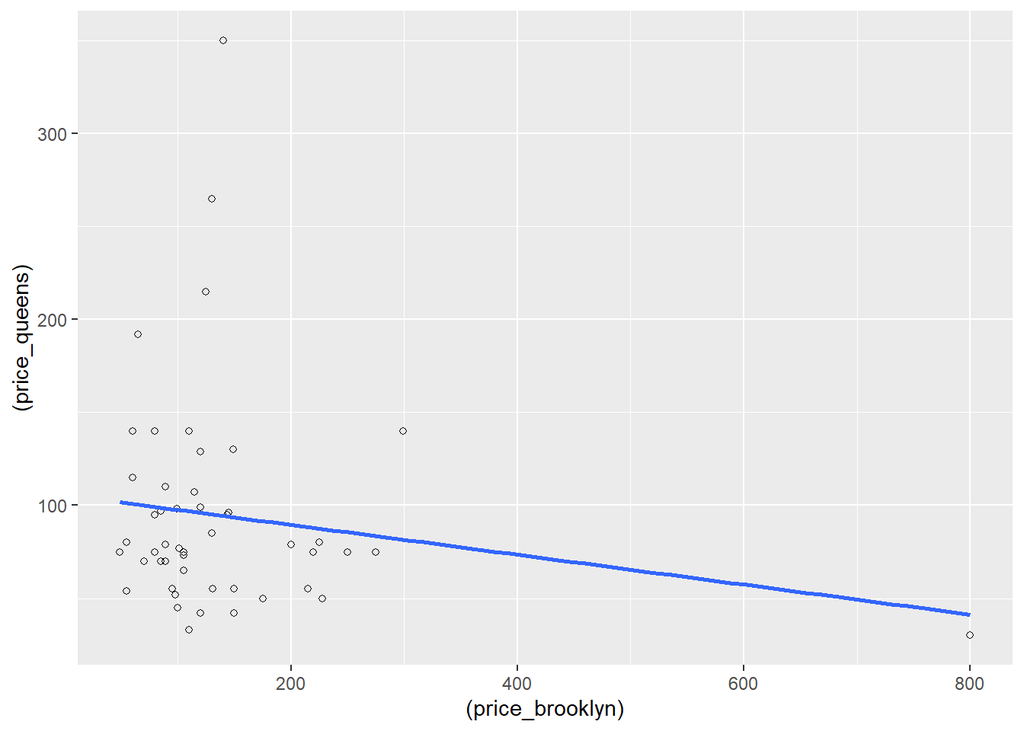

```r
#scatter plot to see correlation between prices of Brooklyn and Queens
# The result shows that the p-value is an extremely small number (<0.05) so we can reject Null hypothesis
library(ggplot2)
ggplot(basket, aes(x=(price_brooklyn), y=(price_queens))) +
    geom_point(shape=1) +    # Use hollow circles
    geom_smooth(method=lm,   # Add linear regression line
                se=FALSE)    # Don't add shaded confidence region
```

1.4.2 Handling Outliers Outliers in dataset Outliers can be harmful because most statistical parameters such as mean, standard deviation and correlation are highly sensitive to outliers. Hence, any statistical calculation based on these parameters is affected by the presence of outliers. Whether it is good or bad to eliminate outliers depends on whether they affect your model positively or negatively. We will be using the IQR (Inter Quartile range) technique to eliminate outliers from specific columns of our dataset. We will be identifying outliers by visualizing them in Boxplots. Boxplots show the median of a dataset along with the first and third quartiles and also the limits beyond which all data values are outliers.

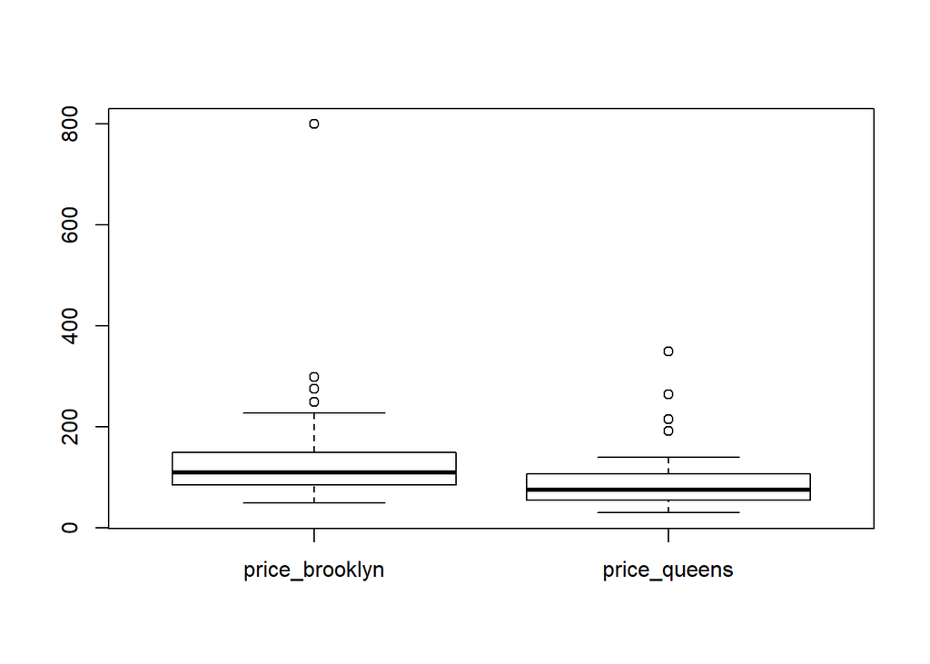

```
## [1] 299 275 800 250 350 265 192 215
```

```r
#Using Boxplot to identify outliers and eliminating them using the Inter quartile range function
boxplot(basket)$out
```

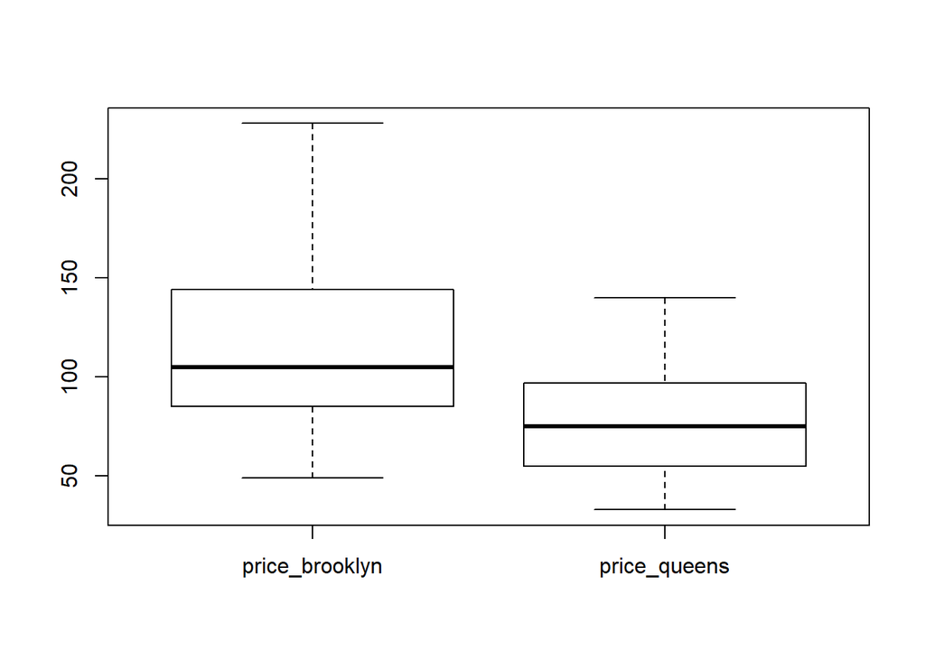

```r
outliers <- function(x) {
  Q1 <- quantile(x, probs=.25)
  Q3 <- quantile(x, probs=.75)
  iqr = Q3-Q1
 upper_limit = Q3 + (iqr*1.5)
 lower_limit = Q1 - (iqr*1.5)
 x > upper_limit | x < lower_limit
}
remove_outliers <- function(df, cols = names(df)) {
  for (col in cols) {
    df <- df[!outliers(df[[col]]),]
  }
  df
}
basket_new<- remove_outliers(basket, c('price_brooklyn', 'price_queens'))
boxplot(basket_new)
```

```r
#After removing outliers run the variances test to check if 2 variables have same variances or not using F test
var.test(basket_new$price_brooklyn, basket_new$price_queens)
```

```
##
##  F test to compare two variances
##
## data:  basket_new$price_brooklyn and basket_new$price_queens
## F = 2.8043, num df = 41, denom df = 41, p-value = 0.001313
## alternative hypothesis: true ratio of variances is not equal to 1
## 95 percent confidence interval:
##  1.507403 5.217161
## sample estimates:
## ratio of variances
##           2.804347
```

```r
#Run a 2 sided T test with unequal variances to accept or reject Null hypothesis
t.test (basket_new$price_brooklyn, basket_new$price_queens, var.equal = FALSE)
```

```
##
##  Welch Two Sample t-test
##
## data:  basket_new$price_brooklyn and basket_new$price_queens
## t = 4.1495, df = 66.942, p-value = 9.613e-05
## alternative hypothesis: true difference in means is not equal to 0
## 95 percent confidence interval:
##  18.39878 52.50598
## sample estimates:
## mean of x mean of y
## 115.97619  80.52381
```

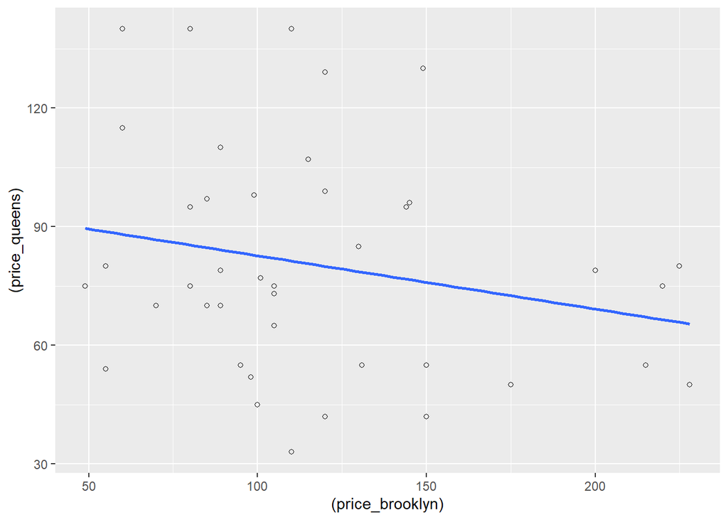

```r
#scatter plot to see negative correlation between prices of Brooklyn and Queens
# The result shows that the p-value is an extremely small number (<0.05) so we can reject Null hypothesis same as original analysis
ggplot(basket_new, aes(x=(price_brooklyn), y=(price_queens))) +
    geom_point(shape=1) +    # Use hollow circles
    geom_smooth(method=lm,   # Add linear regression line
                se=FALSE)
```

Conclusion

After eliminating outliers, the p-value is still less than 0.05 similar to original observation which confirms that we can reject the Null hypothesis and conclude the mean prices of Airbnb in Brooklyn is not same as Mean prices of Airbnb in Queens. Also, the graph now eliminates possible outliers and depicts a negative association between prices of Brooklyn and Queens.

1.4.3 Missing Values Analysis

The next part of Hypothesis 1 is to investigate effect of Missing Values on our hypothesis 1. In statistics, missing values occur when there is no data input for the variable in the observation. Missing data are common occurrence but may have significant impact on conclusions. We will proceed with the dataset that we fixed after removing outliers from previous section. We will be simulating 2 types of Missing Values MCAR and MNAR on our dataset and discuss how we will be handling the missing values and then re analyse and examine the impact for Hypothesis 1. Missing Completely at Random (MCAR)

MCAR stands for Missing Completely at Random where the missing values are unrelated to any feature, just as the name denotes. In MCAR, the propensity for a data point to be missing is completely random. There does not exist any relationship between a data point missing and any values in the data set, observed or missing.

Methodology

Method 1: Using simFrame package to simulate missing values Completely at Random

```r
#install.packages("simFrame")
library(simFrame)
nac<-NAControl(NArate=0.2)
x<-setNA(NYC,nac)
neighbourhood_MAR=as.factor(x$neighbourhood_group)
mymatrix_MAR=matrix(c(neighbourhood_MAR,x$price),ncol = 2,byrow = F)

## method: delete missing values
newdata=na.omit(mymatrix_MAR)
price_brooklyn_MAR=newdata[which(newdata[,1]==2),]
price_queens_MAR=newdata[which(newdata[,1]==4),]

###check equal variance assumption
var.test(price_brooklyn_MAR[,2],price_queens_MAR[,2])
```

```
##
##  F test to compare two variances
##
## data:  price_brooklyn_MAR[, 2] and price_queens_MAR[, 2]
## F = 5.3479, num df = 10563, denom df = 2923, p-value < 2.2e-16
## alternative hypothesis: true ratio of variances is not equal to 1
## 95 percent confidence interval:
##  5.044394 5.664131
## sample estimates:
## ratio of variances
##           5.347865
```

```r
##conclusion: the p-value is extremely small. Implies unequal variance.

###two sample t-test with unequal variance
t.test(price_brooklyn_MAR[,2],price_queens_MAR[,2],var.equal = FALSE)
```

```
##
##  Welch Two Sample t-test
##
## data:  price_brooklyn_MAR[, 2] and price_queens_MAR[, 2]
## t = 12.718, df = 11194, p-value < 2.2e-16
## alternative hypothesis: true difference in means is not equal to 0
## 95 percent confidence interval:
##  25.64261 34.98754
## sample estimates:
## mean of x mean of y
## 122.81986  92.50479
```

Method 2: Using MICE Package to simulate Missing Values Completely at Random

We will be using another method to handle the missing values. Due to incompleteness of missing elements in the Airbnb dataset we use Ampute() function of Mice package in R to insert missing values completely at Random on the entire dataset with a proportion of missingness of 20% and 50%. We will also use Mice which uses multivariate imputations to estimate the missing values. Multiple imputations help in resolving the uncertainty for the missingness. The package regresses over any variable that contains missing values and predicts missing values. One of the available models are PMM (Predictive Mean Matching) which is suitable for numeric variables. For each missing entry, the PMM method creates a reduced set of candidate donors (typically with 3, 5 or 10 members) from all complete cases that have predicted values near to the predicted value for the missing value. One donor is randomly picked from the candidates, and the observed value of the donor replaces the missing value. The assumption is that the distribution of the missing cell is equal to the observed data of the candidate donors.

Using MICE ampute() function at 20% and 50% missing rates

```r
library(mice) ###using Mice function
miss_data.hyp2<-ampute(basket_new,mech="MCAR",prop=0.2) ### using 20% proportion in the ampute() function
md.MCAR.hyp2<-miss_data.hyp2$amp
which(is.na(md.MCAR.hyp2)=="TRUE")
```

```
## [1] 15 17 24 25 50 55 71 79
```

```r
summary(md.MCAR.hyp2) #shows a summary of data of how many Null values inserted
```

```
##  price_brooklyn   price_queens
##  Min.   : 55.0   Min.   : 33.00
##  1st Qu.: 85.0   1st Qu.: 55.00
##  Median :103.0   Median : 75.00
##  Mean   :115.8   Mean   : 78.95
##  3rd Qu.:130.8   3rd Qu.: 95.75
##  Max.   :228.0   Max.   :140.00
##  NA's   :4       NA's   :4
```

```r
#Using library VIM to visualize missing data and if there are any patterns
library (VIM)
```

```
## VIM is ready to use.
##  Since version 4.0.0 the GUI is in its own package VIMGUI.
##
##           Please use the package to use the new (and old) GUI.
```

```
## Suggestions and bug-reports can be submitted at: https://github.com/alexkowa/VIM/issues
```

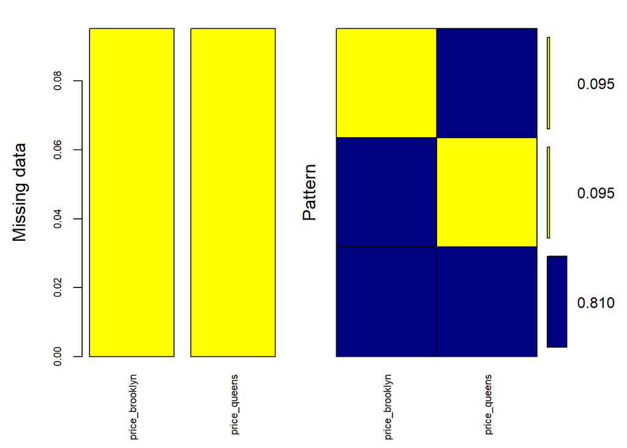

```
##
##  Variables sorted by number of missings:
##        Variable     Count
##  price_brooklyn 0.0952381
##    price_queens 0.0952381
```

```r
mice_plot_MCAR_2 <- aggr(md.MCAR.hyp2, col=c('navyblue', 'yellow'), numbers=TRUE, sortVars=TRUE,
labels=names(md.MCAR.hyp2), cex.axis=.7, gap=3, ylab=c("Missing data", "Pattern"))
```

```r
#Imputing missing data using Mice PMM method (Predictive Mean matching)
mice_imputes_hyp0.2 = mice(md.MCAR.hyp2, m=5, maxit = 40)
mice_imputes_hyp0.2$method
```

```
## price_brooklyn   price_queens
##          "pmm"          "pmm"
```

```r
Imputed_data_hyp0.2_MCAR=complete(mice_imputes_hyp0.2,5)
sapply(Imputed_data_hyp0.2_MCAR, function(x) sum(is.na(x)))
```

```
## price_brooklyn   price_queens
##              0              0
```

```r
##Check variances
var.test(Imputed_data_hyp0.2_MCAR$price_brooklyn,Imputed_data_hyp0.2_MCAR$price_queens)
```

```
##
##  F test to compare two variances
##
## data:  Imputed_data_hyp0.2_MCAR$price_brooklyn and Imputed_data_hyp0.2_MCAR$price_queens
## F = 3.2764, num df = 41, denom df = 41, p-value = 0.0002386
## alternative hypothesis: true ratio of variances is not equal to 1
## 95 percent confidence interval:
##  1.761122 6.095290
## sample estimates:
## ratio of variances
##           3.276363
```

```r
#Check 2 sided sample T test
t.test(Imputed_data_hyp0.2_MCAR$price_brooklyn,Imputed_data_hyp0.2_MCAR$price_queens, var.equal = FALSE)
```

```
##
##  Welch Two Sample t-test
##
## data:  Imputed_data_hyp0.2_MCAR$price_brooklyn and Imputed_data_hyp0.2_MCAR$price_queens
## t = 4.3916, df = 63.895, p-value = 4.319e-05
## alternative hypothesis: true difference in means is not equal to 0
## 95 percent confidence interval:
##  20.83016 55.59841
## sample estimates:
## mean of x mean of y
## 118.76190  80.54762
```

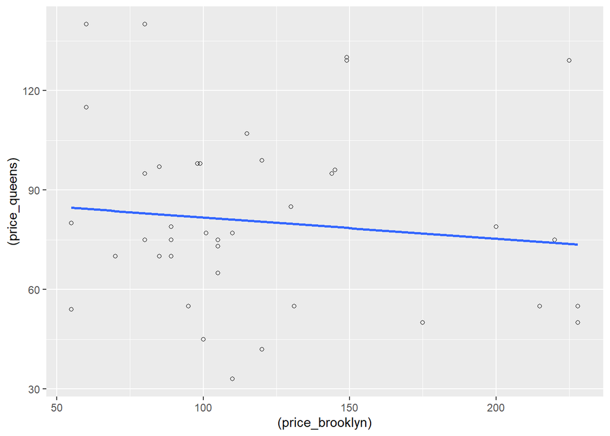

```r
library(ggplot2)
#scatter plot to see negative correlation between prices of Brooklyn and Queens
ggplot(Imputed_data_hyp0.2_MCAR, aes(x=(price_brooklyn), y=(price_queens))) +
    geom_point(shape=1) +    # Use hollow circles
    geom_smooth(method=lm,   # Add linear regression line
                se=FALSE)
```

```r
miss_data.hyp3<-ampute(basket_new,mech="MCAR",prop=0.5) ### using 50% proportion
md.MCAR.hyp3<-miss_data.hyp3$amp
which(is.na(md.MCAR.hyp3)=="TRUE")
```

```
##  [1] 12 15 16 28 30 36 42 47 50 55 64 67 69 71 74 76
```

```r
summary(md.MCAR.hyp3)
```

```
##  price_brooklyn   price_queens
##  Min.   : 49.0   Min.   : 33.00
##  1st Qu.: 85.0   1st Qu.: 55.00
##  Median :101.0   Median : 75.00
##  Mean   :115.7   Mean   : 79.76
##  3rd Qu.:144.5   3rd Qu.: 97.00
##  Max.   :228.0   Max.   :140.00
##  NA's   :7       NA's   :9
```

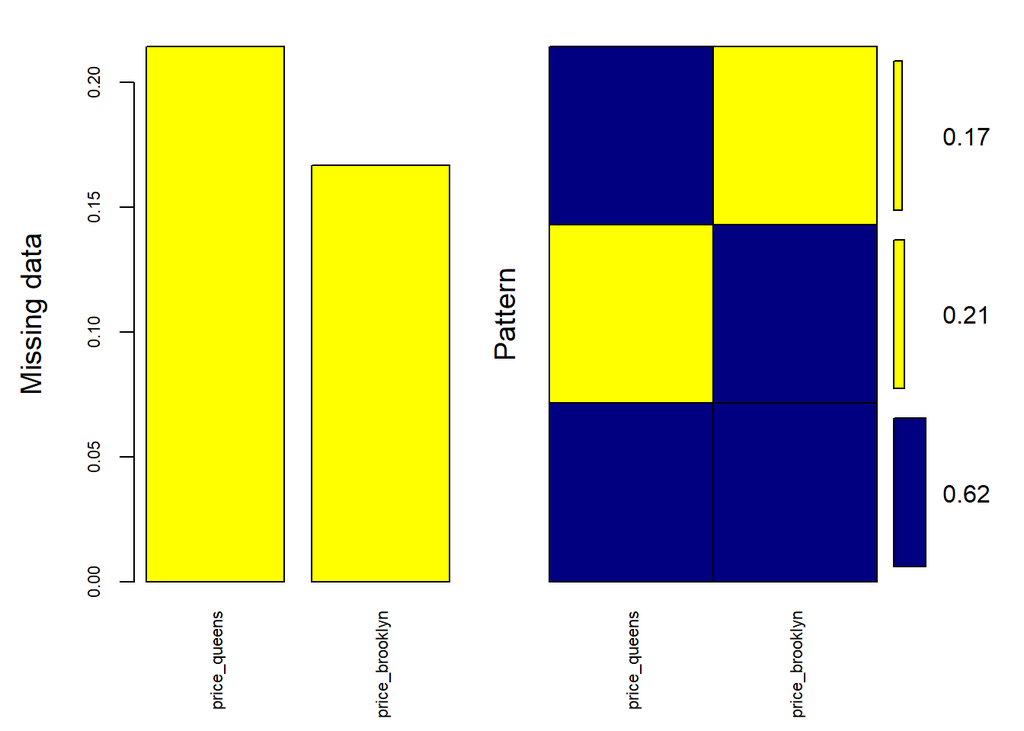

```
##
##  Variables sorted by number of missings:
##        Variable     Count
##    price_queens 0.2142857
##  price_brooklyn 0.1666667
```

```r
#Using library VIM to visualize missing data and if there are any patterns
library (VIM)
mice_plot_MCAR_5 <- aggr(md.MCAR.hyp3, col=c('navyblue', 'yellow'), numbers=TRUE, sortVars=TRUE,
labels=names(md.MCAR.hyp3), cex.axis=.7, gap=3, ylab=c("Missing data", "Pattern"))
```

```r
#imputing missing data
mice_imputes_hyp1 = mice(md.MCAR.hyp3, m=5, maxit = 40)
mice_imputes_hyp1$method
```

```
## price_brooklyn   price_queens
##          "pmm"          "pmm"
```

```r
Imputed_data_hyp1_MCAR=complete(mice_imputes_hyp1,5)
sapply(Imputed_data_hyp1_MCAR, function(x) sum(is.na(x)))
```

```
## price_brooklyn   price_queens
##              0              0
```

```r
##Check Variances using F test
var.test(Imputed_data_hyp1_MCAR$price_brooklyn,Imputed_data_hyp1_MCAR$price_queens)
```

```
##
##  F test to compare two variances
##
## data:  Imputed_data_hyp1_MCAR$price_brooklyn and Imputed_data_hyp1_MCAR$price_queens
## F = 3.5952, num df = 41, denom df = 41, p-value = 7.974e-05
## alternative hypothesis: true ratio of variances is not equal to 1
## 95 percent confidence interval:
##  1.932497 6.688421
## sample estimates:
## ratio of variances
##           3.595184
```

```r
## 2 sided sample T test
t.test(Imputed_data_hyp1_MCAR$price_brooklyn, Imputed_data_hyp1_MCAR$price_queens, var.equal = FALSE)
```

```
##
##  Welch Two Sample t-test
##
## data:  Imputed_data_hyp1_MCAR$price_brooklyn and Imputed_data_hyp1_MCAR$price_queens
## t = 5.0691, df = 62.17, p-value = 3.846e-06
## alternative hypothesis: true difference in means is not equal to 0
## 95 percent confidence interval:
##  27.25559 62.74441
## sample estimates:
## mean of x mean of y
##  121.7619   76.7619
```

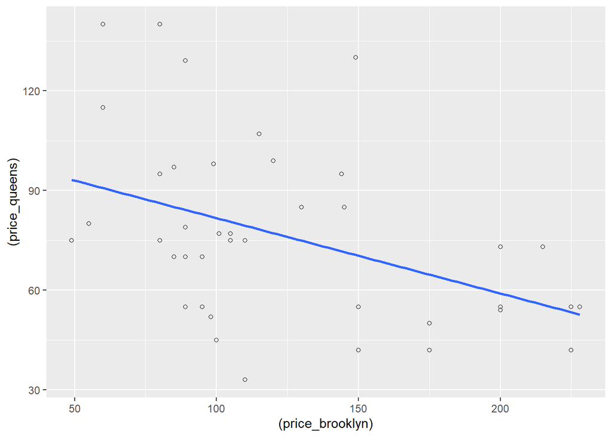

```r
ggplot(Imputed_data_hyp1_MCAR, aes(x=(price_brooklyn), y=(price_queens))) +
    geom_point(shape=1) +    # Use hollow circles
    geom_smooth(method=lm,   # Add linear regression line
                se=FALSE)    # Don't add shaded confidence region
```

Missing Not at Random (MNAR)

MNAR means that the probability of data missing varies for reasons that are unknown to us. For example, the weighing scale mechanism may wear out as time passes and can produce more missing data as time progresses but that is something we may fail to notice.

In this project, we will be using 2 methods to analyse MNAR values - Replacing the first 1000 elements in the price of hotels in Brooklyn with missing variables and second method is the Mice package to simulate MNAR values and estimating MNAR values using PMM (predictive mean matching technique).After simulating the missing data, we will check equal variances assumption and 2-sided T- test to check if price of Airbnb hotels in Queens is different from the price of Airbnb hotels in Brooklyn

Methodology

Method 1: We replace the first 1000 elements in the price of hotels in Brooklyn with missing variables. This case the missing values are non-ignorable missing values. We use na.omit function to delete all missing not at random values

```r
price_brooklyn_MNAR=replace(price_brooklyn[,2],1:1000,NA)
# We decided to replace first 1000 values in price in Brooklyn to be missing values
# Instead of missing at random, this time we made variables missing not at random
# and keep price in Queens complete.
new_price_brooklyn_MNAR=na.omit(price_brooklyn_MNAR)
###check equal variance assumption
var.test(new_price_brooklyn_MNAR,price_queens[,2])
```

```
##
##  F test to compare two variances
##
## data:  new_price_brooklyn_MNAR and price_queens[, 2]
## F = 1.057, num df = 15440, denom df = 4571, p-value = 0.02085
## alternative hypothesis: true ratio of variances is not equal to 1
## 95 percent confidence interval:
##  1.008465 1.107146
## sample estimates:
## ratio of variances
##           1.056971
```

```r
##conclusion: the p-value is extremely small. Implies unequal variance.

###two sample t-test with unequal variance
t.test(new_price_brooklyn_MNAR,price_queens_MAR[,2],var.equal = FALSE)
```

```
##
##  Welch Two Sample t-test
##
## data:  new_price_brooklyn_MNAR and price_queens_MAR[, 2]
## t = 13.358, df = 8781.3, p-value < 2.2e-16
## alternative hypothesis: true difference in means is not equal to 0
## 95 percent confidence interval:
##  23.44684 31.51198
## sample estimates:
## mean of x mean of y
## 119.98420  92.50479
```

Method 2: Using MICE Package to simulate Missing Values Not at Random

Similarly as MCAR, we feed in desired columns of the Airbnb dataset into the Ampute() function setting method as MNAR in the Mice library package to simulate missing values Not at Random with a proportion of missingness equal to 20% and 50%. We then use Mice to estimate the missing values using multiple imputation technique like PMM. Multiple imputations help in resolving the uncertainty for the missingness. The package regresses over any variable that contains missing values and predicts missing values. After simulating missing values not at random in our dataset we imply the Equal Variances assumption to check if 2 variables have the same variances or not and a two tailed T test to accept or reject hypothesis 1.

```r
library(mice) ###using Mice function
miss_data.hyp1<-ampute(basket_new,mech="MNAR",prop=0.2) ### using 20% proportion
md.MNAR.hyp4<-miss_data.hyp1$amp
which(is.na(md.MNAR.hyp4)=="TRUE")
```

```
## [1] 21 26 29 39 40 50
```

```r
summary(md.MNAR.hyp4)
```

```
##  price_brooklyn   price_queens
##  Min.   : 49.0   Min.   : 33.00
##  1st Qu.: 85.0   1st Qu.: 55.00
##  Median :105.0   Median : 75.00
##  Mean   :113.7   Mean   : 79.07
##  3rd Qu.:131.0   3rd Qu.: 96.00
##  Max.   :228.0   Max.   :140.00
##  NA's   :5       NA's   :1
```

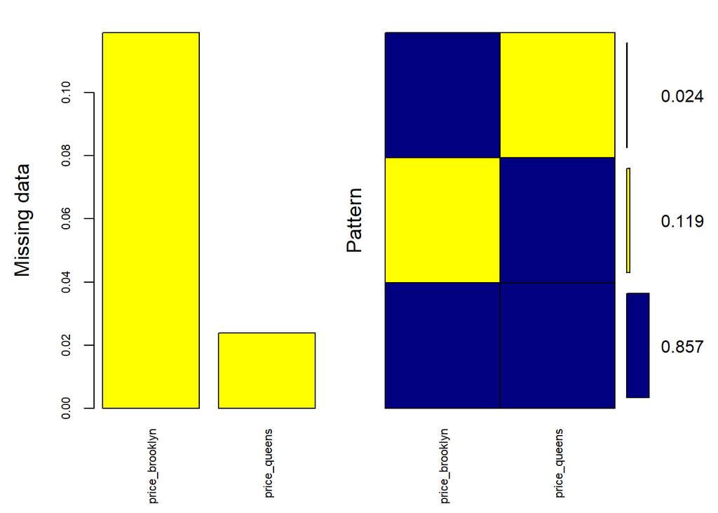

```
##
##  Variables sorted by number of missings:
##        Variable      Count
##  price_brooklyn 0.11904762
##    price_queens 0.02380952
```

```r
library (VIM)
mice_plot_MNAR_2 <- aggr(md.MNAR.hyp4, col=c('navyblue', 'yellow'), numbers=TRUE, sortVars=TRUE,
labels=names(md.MNAR.hyp4), cex.axis=.7, gap=3, ylab=c("Missing data", "Pattern"))
```

```r
#Estimating missing data
mice_imputes_MNAR_0.2 = mice(md.MNAR.hyp4, m=5, maxit = 30)
mice_imputes_MNAR_0.2$method
```

```
## price_brooklyn   price_queens
##          "pmm"          "pmm"
```

```r
Imputed_data_hyp0.2_MNAR=complete(mice_imputes_MNAR_0.2,5)
sapply(Imputed_data_hyp0.2_MNAR, function(x) sum(is.na(x)))
```

```
## price_brooklyn   price_queens
##              0              0
```

```r
#Check Variances
var.test(Imputed_data_hyp0.2_MNAR$price_brooklyn,Imputed_data_hyp0.2_MNAR$price_queens)
```

```
##
##  F test to compare two variances
##
## data:  Imputed_data_hyp0.2_MNAR$price_brooklyn and Imputed_data_hyp0.2_MNAR$price_queens
## F = 2.6906, num df = 41, denom df = 41, p-value = 0.002009
## alternative hypothesis: true ratio of variances is not equal to 1
## 95 percent confidence interval:
##  1.446256 5.005529
## sample estimates:
## ratio of variances
##            2.69059
```

```r
#2 sided T test
t.test(Imputed_data_hyp0.2_MNAR$price_brooklyn, Imputed_data_hyp0.2_MNAR$price_queens, var.equal = FALSE)
```

```
##
##  Welch Two Sample t-test
##
## data:  Imputed_data_hyp0.2_MNAR$price_brooklyn and Imputed_data_hyp0.2_MNAR$price_queens
## t = 4.1757, df = 67.778, p-value = 8.676e-05
## alternative hypothesis: true difference in means is not equal to 0
## 95 percent confidence interval:
##  18.01239 50.98761
## sample estimates:
## mean of x mean of y
##  114.7619   80.2619
```

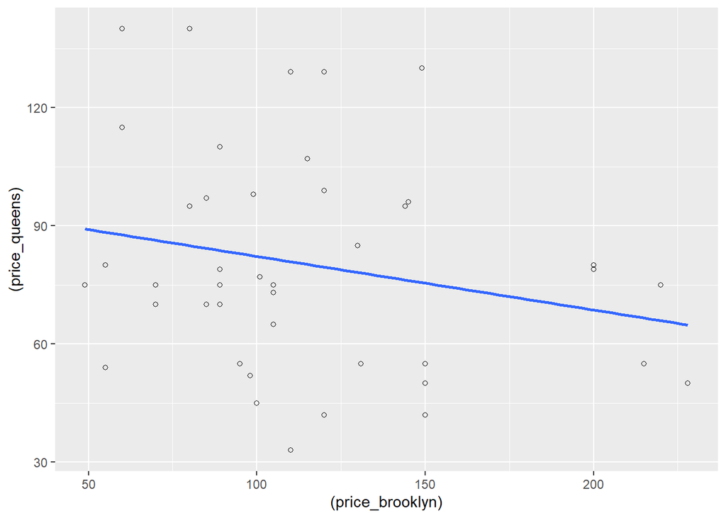

```r
ggplot(Imputed_data_hyp0.2_MNAR, aes(x=(price_brooklyn), y=(price_queens))) +
    geom_point(shape=1) +    # Use hollow circles
    geom_smooth(method=lm,   # Add linear regression line
                se=FALSE)    # Don't add shaded confidence region
```

```r
miss_data.hyp4<-ampute(basket_new,mech="MNAR",prop=0.5) ### using 50% proportion with ampute function
md.MNAR.hyp5<-miss_data.hyp4$amp
which(is.na(md.MNAR.hyp5)=="TRUE")
```

```
##  [1]  8  9 17 18 23 24 29 36 42 43 44 45 47 48 55 57 61 68
```

```r
summary(md.MNAR.hyp5)
```

```
##  price_brooklyn   price_queens
##  Min.   : 49.0   Min.   : 33.00
##  1st Qu.: 80.0   1st Qu.: 55.00
##  Median : 98.0   Median : 75.00
##  Mean   :106.4   Mean   : 74.79
##  3rd Qu.:120.0   3rd Qu.: 85.00
##  Max.   :228.0   Max.   :140.00
##  NA's   :9       NA's   :9
```

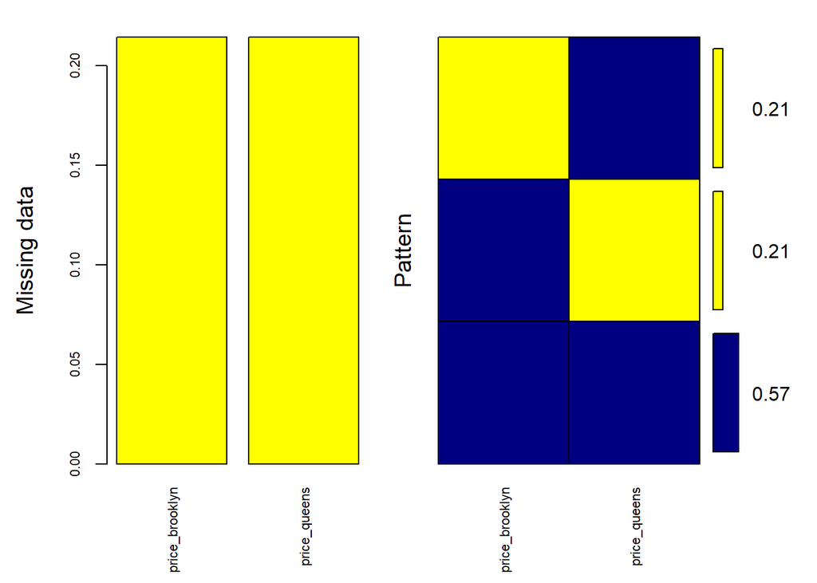

```
##
##  Variables sorted by number of missings:
##        Variable     Count
##  price_brooklyn 0.2142857
##    price_queens 0.2142857
```

```r
#Visualize missing pattern
library (VIM)
mice_plot_MNAR_5 <- aggr(md.MNAR.hyp5, col=c('navyblue', 'yellow'), numbers=TRUE, sortVars=TRUE,
labels=names(md.MNAR.hyp5), cex.axis=.7, gap=3, ylab=c("Missing data", "Pattern"))
```

```r
mice_imputes_MNAR_0.5 = mice(md.MNAR.hyp5, m=5, maxit = 30)
mice_imputes_MNAR_0.5$method
```

```
## price_brooklyn   price_queens
##          "pmm"          "pmm"
```

```r
Imputed_data_hyp0.5_MNAR=complete(mice_imputes_MNAR_0.5,5)
sapply(Imputed_data_hyp0.5_MNAR, function(x) sum(is.na(x)))
```

```
## price_brooklyn   price_queens
##              0              0
```

```r
#Check for variances
var.test(Imputed_data_hyp0.5_MNAR$price_brooklyn,Imputed_data_hyp0.5_MNAR$price_queens)
```

```
##
##  F test to compare two variances
##
## data:  Imputed_data_hyp0.5_MNAR$price_brooklyn and Imputed_data_hyp0.5_MNAR$price_queens
## F = 2.5034, num df = 41, denom df = 41, p-value = 0.004086
## alternative hypothesis: true ratio of variances is not equal to 1
## 95 percent confidence interval:
##  1.345651 4.657332
## sample estimates:
## ratio of variances
##           2.503426
```

```r
#Check 2 sided T test using unequal variances
t.test(Imputed_data_hyp0.5_MNAR$price_brooklyn, Imputed_data_hyp0.5_MNAR$price_queens, var.equal = FALSE)
```

```
##
##  Welch Two Sample t-test
##
## data:  Imputed_data_hyp0.5_MNAR$price_brooklyn and Imputed_data_hyp0.5_MNAR$price_queens
## t = 4.1378, df = 69.248, p-value = 9.712e-05
## alternative hypothesis: true difference in means is not equal to 0
## 95 percent confidence interval:
##  15.72224 44.99205
## sample estimates:
## mean of x mean of y
## 103.02381  72.66667
```

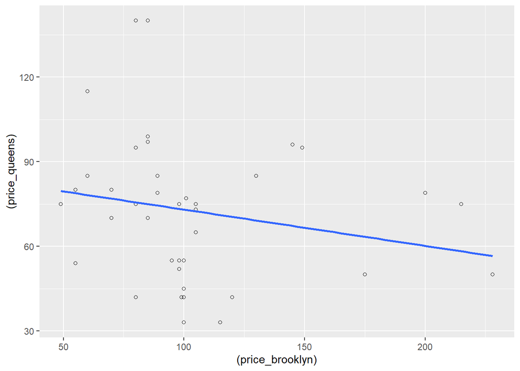

```r
#ggplot to visualize negative correlation between brooklyn and Queens prices
ggplot(Imputed_data_hyp0.5_MNAR, aes(x=(price_brooklyn), y=(price_queens))) +
    geom_point(shape=1) +    # Use hollow circles
    geom_smooth(method=lm,   # Add linear regression line
                se=FALSE)    # Don't add shaded confidence region
```

1.4 Hypothesis 2 – Advanced Model: Multi Linear Regression

Hypothesis 2: Does the neighbourhood, latitude, longitude, room type, minimum nights, number of reviews, reviews per month, calculated host listing count and availability (365 days) affect the price of Airbnb in NYC? We will also compare the reduced model with full model (with all parameters) and check if it is a better fit or not. H0: β1 = β2 = β3 = β4 = β5 = β5 = β6 = β7 = β8 = β9 = 0 H1: At least one of β1, β2, β3, β4, β5, β6, β7, β8, β9 ≠ 0

Data Assumptions of Multi Linear Regression

The regression coefficient β1 is interpreted as the expected change in Y associated with a 1-unit increase in x1 while x2,…, xp are held fixed. A linear regression model that contains greater than one predictor variable is called a multiple linear regression model. For example: the below model is a multiple linear regression model with two predictor variables, x1 and x2. The model is linear because it is linear in the parameters β0, β1 and β2

Y=β0+β1x1+β2x2+ϵ

Dependent Variable: In our hypothesis, the dependent variable is price (Y). Independent Variable: The independent variables x1, x2, x3, x4, x5, x6, x7, x8, x9 in the dataset are neighborhood groups, latitude, longitude, room type, minimum nights people stayed, number of reviews, reviews per month, calculated host listing count and availability_365.

Below we produce a table of Pearson’s correlation coefficients. From this output table, we can see that longitude has the strongest relationship with price (r = -0.16), and reviews per month has the weakest correlation with price (Y).

```r
library(readr)
library(dplyr)
```

```r
library(corrplot)
library(ggplot2)
filtered<-NYC[c(10,7,8,11,12,14,15,16)]
##pearson table(Non numerical factors are not included, e.g. neighbourhood_group and room_type)
res <- cor(filtered)
round(res, 2)
```

```
##                                price latitude longitude minimum_nights
## price                           1.00     0.03     -0.16           0.03
## latitude                        0.03     1.00      0.09           0.02
## longitude                      -0.16     0.09      1.00          -0.06
## minimum_nights                  0.03     0.02     -0.06           1.00
## number_of_reviews              -0.04    -0.01      0.05          -0.07
## reviews_per_month              -0.03    -0.01      0.15          -0.12
## calculated_host_listings_count  0.05     0.00     -0.09           0.07
## availability_365                0.08    -0.02      0.10           0.10
##                                number_of_reviews reviews_per_month
## price                                      -0.04             -0.03
## latitude                                   -0.01             -0.01
## longitude                                   0.05              0.15
## minimum_nights                             -0.07             -0.12
## number_of_reviews                           1.00              0.55
## reviews_per_month                           0.55              1.00
## calculated_host_listings_count             -0.06             -0.01
## availability_365                            0.19              0.19
##                                calculated_host_listings_count availability_365
## price                                                    0.05             0.08
## latitude                                                 0.00            -0.02
## longitude                                               -0.09             0.10
## minimum_nights                                           0.07             0.10
## number_of_reviews                                       -0.06             0.19
## reviews_per_month                                       -0.01             0.19
## calculated_host_listings_count                           1.00             0.18
## availability_365                                         0.18             1.00
```

```r
##first linear regression model
model <- lm(price ~ latitude + longitude + room_type + minimum_nights  + number_of_reviews + reviews_per_month + calculated_host_listings_count+ availability_365 + neighbourhood_group, data = NYC)
summary(model)
```

```
##
## Call:
## lm(formula = price ~ latitude + longitude + room_type + minimum_nights +
##     number_of_reviews + reviews_per_month + calculated_host_listings_count +
##     availability_365 + neighbourhood_group, data = NYC)
##
## Residuals:
##    Min     1Q Median     3Q    Max
## -210.2  -52.9  -18.2   17.0 9966.8
##
## Coefficients:
##                                    Estimate Std. Error t value Pr(>|t|)
## (Intercept)                      -2.670e+04  2.892e+03  -9.232  < 2e-16 ***
## latitude                         -1.492e+02  2.848e+01  -5.240 1.62e-07 ***
## longitude                        -4.456e+02  3.248e+01 -13.717  < 2e-16 ***
## room_typePrivate room            -1.007e+02  1.955e+00 -51.522  < 2e-16 ***
## room_typeShared room             -1.359e+02  6.522e+00 -20.837  < 2e-16 ***
## minimum_nights                   -2.113e-01  5.514e-02  -3.832 0.000127 ***
## number_of_reviews                -1.952e-01  2.366e-02  -8.250  < 2e-16 ***
## reviews_per_month                 1.203e-01  6.855e-01   0.176 0.860672
## calculated_host_listings_count   -9.465e-02  3.713e-02  -2.549 0.010811 *
## availability_365                  1.735e-01  7.753e-03  22.378  < 2e-16 ***
## neighbourhood_groupBrooklyn      -1.693e+01  7.964e+00  -2.126 0.033499 *
## neighbourhood_groupManhattan      3.329e+01  7.210e+00   4.616 3.92e-06 ***
## neighbourhood_groupQueens         5.044e+00  7.653e+00   0.659 0.509887
## neighbourhood_groupStaten Island -1.425e+02  1.494e+01  -9.536  < 2e-16 ***
## ---
## Signif. codes:  0 '***' 0.001 '**' 0.01 '*' 0.05 '.' 0.1 ' ' 1
##
## Residual standard error: 185 on 38813 degrees of freedom
## Multiple R-squared:  0.118,  Adjusted R-squared:  0.1178
## F-statistic: 399.6 on 13 and 38813 DF,  p-value: < 2.2e-16
```

```r
#Using Anova
anova(model)
```

|  | Df | Sum Sq | Mean Sq | F value | Pr(>F) |
| --- | --- | --- | --- | --- | --- |
| latitude | 1 | 1.481980e+06 | 1481979.63 | 43.2914690 | 4.776225e-11 |
| longitude | 1 | 3.794932e+07 | 37949320.85 | 1108.5724864 | 1.085157e-239 |
| room_type | 2 | 1.053300e+08 | 52665000.14 | 1538.4457176 | 0.000000e+00 |
| minimum_nights | 1 | 3.518950e+03 | 3518.95 | 0.1027953 | 7.485023e-01 |
| number_of_reviews | 1 | 9.853484e+05 | 985348.41 | 28.7839179 | 8.138279e-08 |
| reviews_per_month | 1 | 2.619553e+05 | 261955.27 | 7.6522160 | 5.672944e-03 |
| calculated_host_listings_count | 1 | 6.542993e+05 | 654299.29 | 19.1133379 | 1.235010e-05 |
| availability_365 | 1 | 1.668141e+07 | 16681412.61 | 487.2960737 | 2.532851e-107 |
| neighbourhood_group | 4 | 1.449463e+07 | 3623658.34 | 105.8540138 | 7.539813e-90 |
| Residuals | 38813 | 1.328670e+09 | 34232.60 | NA | NA |

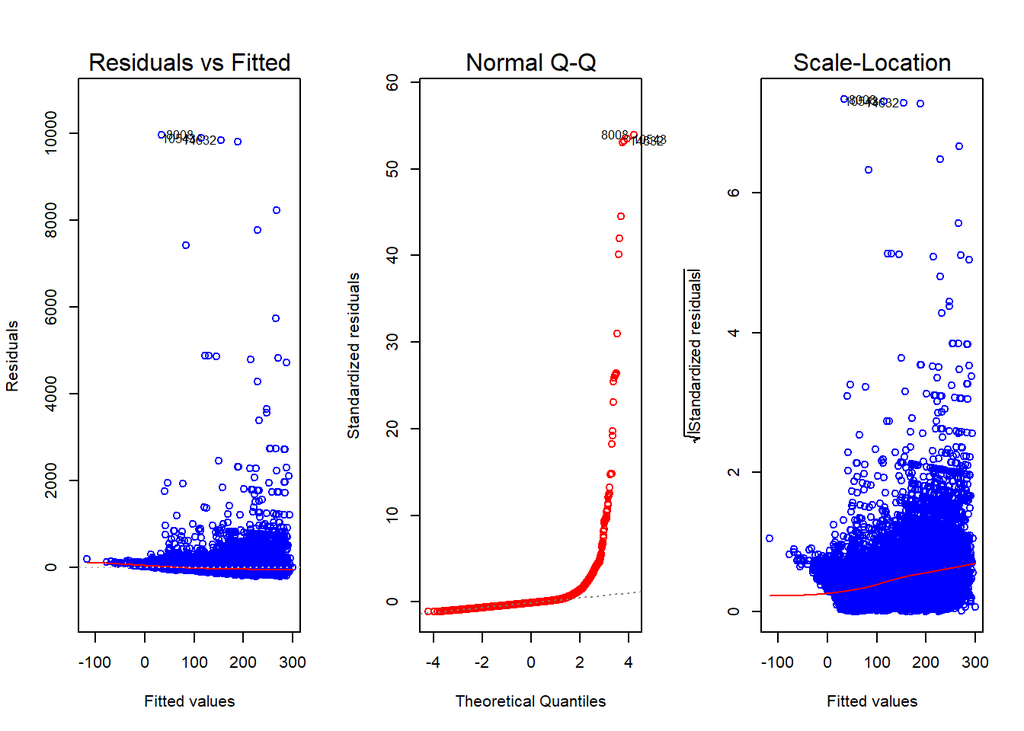

```r
#Residual Analysis
par(mfrow=c(1,3))
plot(model, which=1, col=c("blue")) # Residuals vs Fitted Plot
plot(model, which=2, col=c("red"))  # Q-Q Plot
plot(model, which=3, col=c("blue"))  # Scale-Location Plot
```

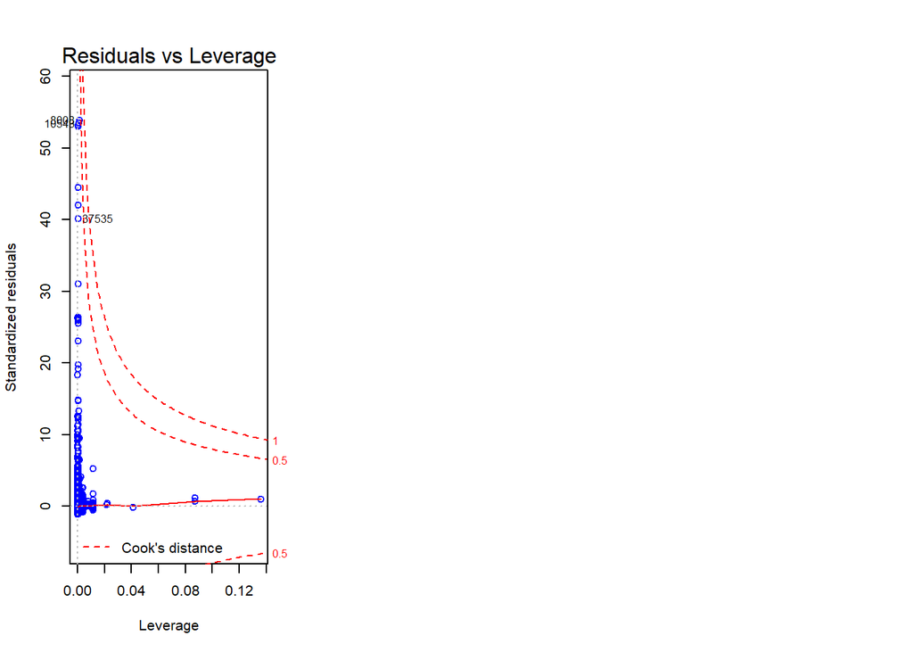

```r
plot(model, which=5, col=c("blue"))  # Residuals vs Leverage
```

Conclusion

The summary() table contains the coefficients for the regression equation, tests of significance for each variable and R squared value. The last column contains the p-values for each of the independent variables. The hypothesis being tested for each is that the coefficient is 0 after controlling for the other variables. For example, let’s say the effects of other variables are removed before assessing the relationship between the latitude and price. A p-value < 0.05, provides evidence that the coefficient is different to 0. We can see that the results of the full model linear regression (with all parameters) show the significance of each individual variable, where majority of the parameters are significant at the 5% level. But, the multiple R-squared value is 0.1181 or 11.8% which is much less than 0.5, so the linear relationship is not obvious.

Also, from the Normal Q-Q plot, we can see that it does not satisfy linear model assumptions (Normal Q-Q plot should be straight line). So, we built the second model by removing possible outliers.

```r
## second model after removing outliers
NYC1 <- NYC %>% mutate(id = row_number())
AB_NYC_2019_model2 <- NYC1 %>% sample_frac(.7) %>% filter(price > 0)

my_data <- AB_NYC_2019_model2 %>% filter(price < quantile(AB_NYC_2019_model2$price, 0.9) & price > quantile(AB_NYC_2019_model2$price, 0.1)) %>% tidyr::drop_na()
#Running regression 2
model2 <- lm(log(price) ~ latitude + longitude + room_type + minimum_nights  + number_of_reviews + reviews_per_month + calculated_host_listings_count+ availability_365 + neighbourhood_group, data = my_data)
summary(model2) #summarize coefficients table
```

```
##
## Call:
## lm(formula = log(price) ~ latitude + longitude + room_type +
##     minimum_nights + number_of_reviews + reviews_per_month +
##     calculated_host_listings_count + availability_365 + neighbourhood_group,
##     data = my_data)
##
## Residuals:
##      Min       1Q   Median       3Q      Max
## -1.15454 -0.21692 -0.01074  0.20554  1.40142
##
## Coefficients:
##                                    Estimate Std. Error  t value Pr(>|t|)
## (Intercept)                      -1.300e+02  6.467e+00  -20.101  < 2e-16 ***
## latitude                         -4.648e-01  6.326e-02   -7.348 2.09e-13 ***
## longitude                        -2.079e+00  7.285e-02  -28.541  < 2e-16 ***
## room_typePrivate room            -5.181e-01  4.309e-03 -120.225  < 2e-16 ***
## room_typeShared room             -6.361e-01  1.997e-02  -31.858  < 2e-16 ***
## minimum_nights                   -1.393e-03  1.276e-04  -10.920  < 2e-16 ***
## number_of_reviews                -1.754e-05  5.228e-05   -0.336   0.7372
## reviews_per_month                -1.769e-03  1.570e-03   -1.126   0.2600
## calculated_host_listings_count    5.018e-04  9.149e-05    5.484 4.19e-08 ***
## availability_365                  3.053e-04  1.784e-05   17.112  < 2e-16 ***
## neighbourhood_groupBrooklyn      -3.912e-02  1.869e-02   -2.093   0.0364 *
## neighbourhood_groupManhattan      1.462e-01  1.711e-02    8.543  < 2e-16 ***
## neighbourhood_groupQueens         4.630e-02  1.807e-02    2.562   0.0104 *
## neighbourhood_groupStaten Island -5.669e-01  3.421e-02  -16.572  < 2e-16 ***
## ---
## Signif. codes:  0 '***' 0.001 '**' 0.01 '*' 0.05 '.' 0.1 ' ' 1
##
## Residual standard error: 0.3069 on 21418 degrees of freedom
## Multiple R-squared:  0.4939, Adjusted R-squared:  0.4936
## F-statistic:  1608 on 13 and 21418 DF,  p-value: < 2.2e-16
```

```r
#ANOVA
anova(model2)
```

|  | Df | Sum Sq | Mean Sq | F value | Pr(>F) |
| --- | --- | --- | --- | --- | --- |
| latitude | 1 | 5.555785e+00 | 5.55578537 | 59.0006535 | 1.643680e-14 |
| longitude | 1 | 3.459588e+02 | 345.95878234 | 3673.9709838 | 0.000000e+00 |
| room_type | 2 | 1.449912e+03 | 724.95624677 | 7698.8021438 | 0.000000e+00 |
| minimum_nights | 1 | 4.874702e+00 | 4.87470201 | 51.7677673 | 6.452788e-13 |
| number_of_reviews | 1 | 3.087774e-01 | 0.30877743 | 3.2791170 | 7.018068e-02 |
| reviews_per_month | 1 | 8.702463e-02 | 0.08702463 | 0.9241736 | 3.363924e-01 |
| calculated_host_listings_count | 1 | 1.789367e+01 | 17.89367166 | 190.0250371 | 4.794602e-43 |
| availability_365 | 1 | 2.259634e+01 | 22.59634458 | 239.9659108 | 7.839670e-54 |
| neighbourhood_group | 4 | 1.209300e+02 | 30.23249907 | 321.0594152 | 9.017625e-269 |
| Residuals | 21418 | 2.016822e+03 | 0.09416481 | NA | NA |

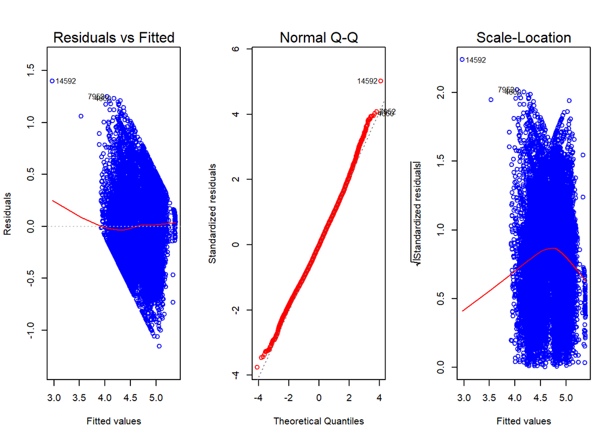

```r
#Residual Analysis
par(mfrow=c(1,3))
plot(model2, which=1, col=c("blue")) # Residuals vs Fitted Plot
plot(model2, which=2, col=c("red"))  # Q-Q Plot
plot(model2, which=3, col=c("blue"))  # Scale-Location Plot
```

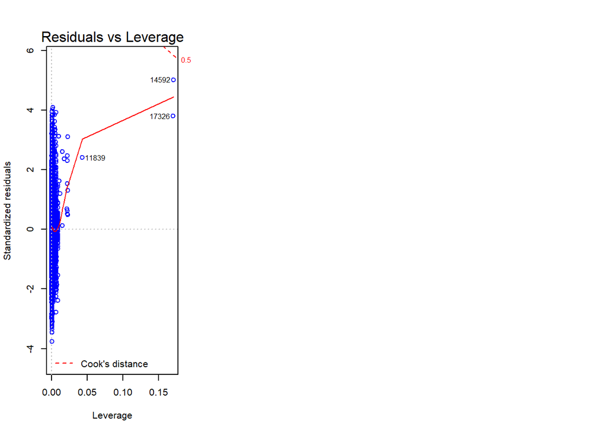

```r
plot(model2, which=5, col=c("blue"))  # Residuals vs Leverage
```

Conclusion